# R Notebook

```r
library(tidyverse)
library(recommenderlab)
library(ggplot2)
install.packages("styler")
```

```r
# get data from recommederlab package
data("MovieLense")

# transform data from Realratingmatrix to Matrix
MovieLenseMatrix <- as(MovieLense, "matrix")
```

1. Welches sind die am häufigsten geschauten Filme?

```r
head(sort(colCounts(MovieLense), decreasing = TRUE), 10) ## top 10 Filme mit den meisten Ratings
```

```
             Star Wars (1977)                Contact (1997)                  Fargo (1996)     Return of the Jedi (1983)
                          583                           509                           508                           507
             Liar Liar (1997)   English Patient, The (1996)                 Scream (1996)              Toy Story (1995)
                          485                           481                           478                           452
         Air Force One (1997) Independence Day (ID4) (1996)
                          431                           429
```

Welches sind die meist geschauten Genres?

```r
watched_movies <- colCounts(MovieLense) ## Vektor mit views pro Film

MovieLense_movies <- MovieLenseMeta %>% ## Kopie von MovieLenseMeta nur mit Genres und Title
  select(title, Action:Western)
```

```r
## Mit zwei for loops durch das Dataframe MovieLense_movies loopen um die Anzahl views pro Film einzutragen
n <- 0
for (x in watched_movies) {
  n <- n + 1
  for (i in 2:19) {
    if (MovieLense_movies[n,i] == 1) {
      MovieLense_movies[n,i] <- x
    }
  }
}
```

```r
head(sort(colSums(MovieLense_movies[,2:19]), decreasing = TRUE),10) ## Anzahl views pro Genre
```

```
     Drama     Comedy     Action   Thriller    Romance  Adventure     Sci-Fi        War      Crime Children's
     39446      29778      25510      21808      19203      13688      12694       9398       8027       7143
```

3. Wie verteilen sich die mittleren Kundenratings pro Film?

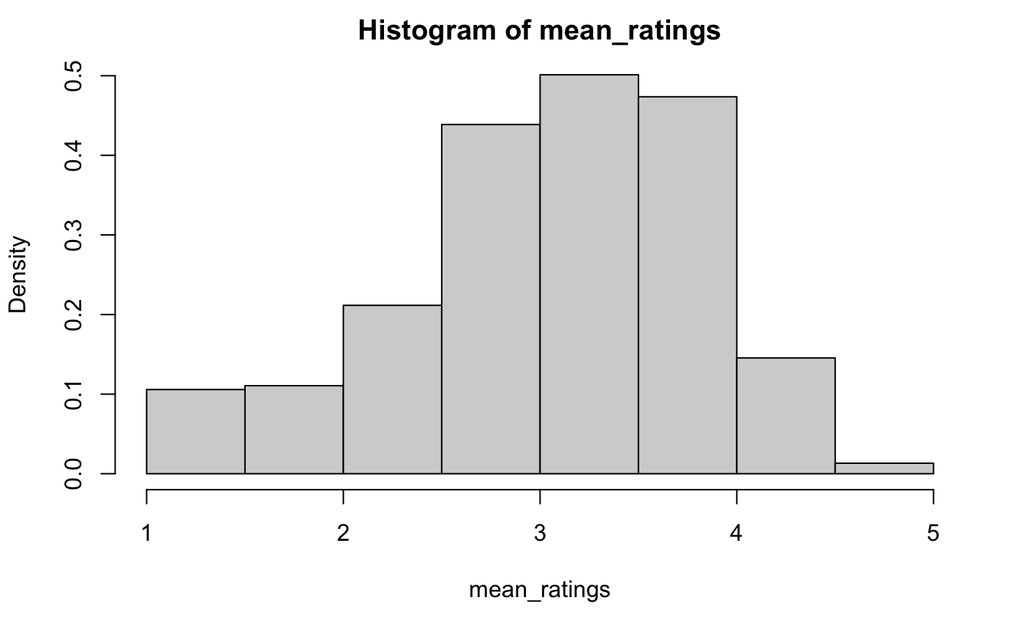

```r
mean_ratings <- colSums(MovieLense)/colCounts(MovieLense)
hist(mean_ratings, probability = TRUE)
```

4. Wie stark streuen die Ratings von individuellen Kunden?
5. Welchen Einfluss hat die Normierung der Ratings pro Kunde auf deren Verteilung?

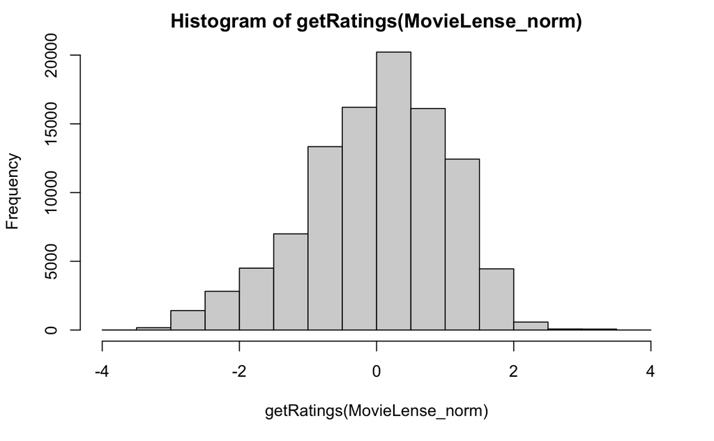

```r
MovieLense_norm <- normalize(MovieLense, method="center", row=TRUE)

hist(getRatings(MovieLense_norm))
```

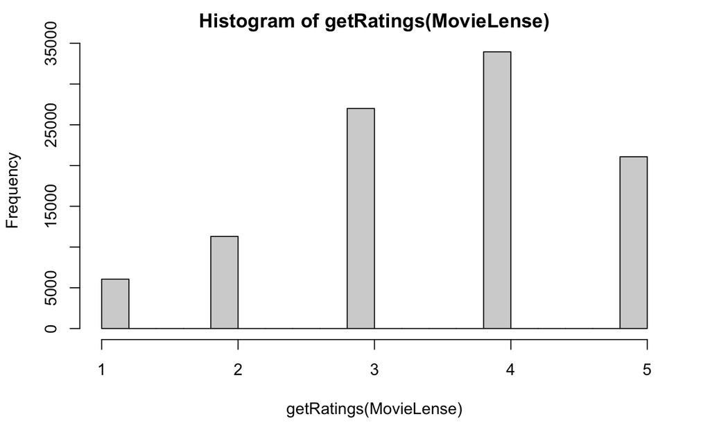

```r
hist(getRatings(MovieLense))
```

6. Welche strukturellen Charakteristika (z.B. Sparsity) und Auffälligkeiten zeigt die User-Item Matrix?

```r
# sparsity
sum(is.na(MovieLenseMatrix) == TRUE)/(dim(MovieLenseMatrix)[1]*dim(MovieLenseMatrix)[2])
```

```
[1] 0.9366588
```

```r
# Dimensions
dim(MovieLense)
```

```
[1]  943 1664
```

```r
# Filme
dim(MovieLense)[1]
```

```
[1] 943
```

```r
# User
dim(MovieLense)[2]
```

```
[1] 1664
```

```r
#
```

Datenreduktion

Wie viele Ratings haben Kunden im Durchschnitt abgegeben?

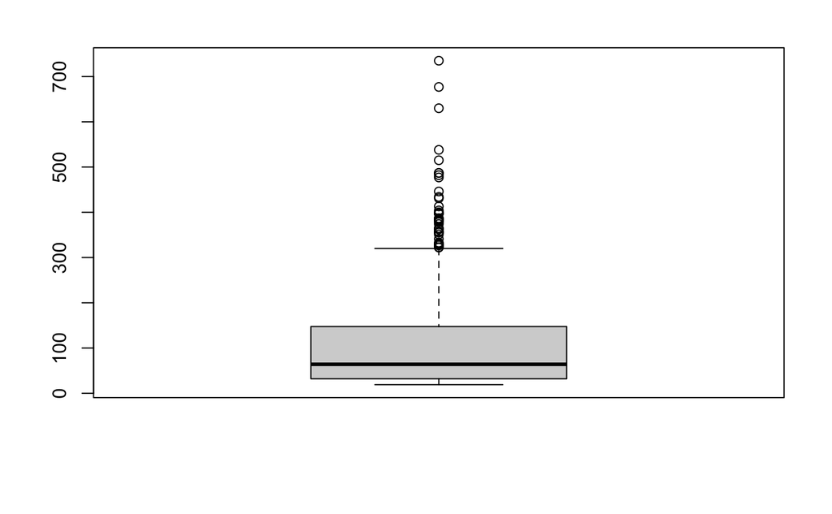

```r
boxplot(rowCounts(MovieLense))
```

```r
print(quantile(rowCounts(MovieLense)))
```

```
   0%   25%   50%   75%  100%
 19.0  32.0  64.0 147.5 735.0
```

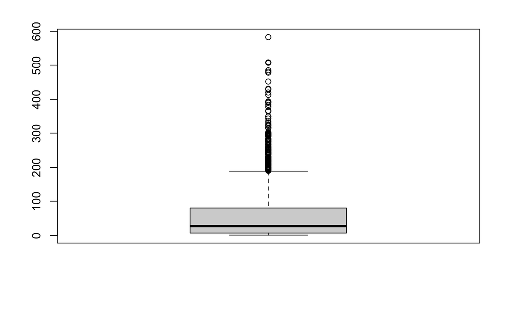

```r
boxplot(colCounts(MovieLense))
```

```r
print(quantile(colCounts(MovieLense)))
```

```
  0%  25%  50%  75% 100%
   1    7   27   80  583
```

## Test train split für drei Personen, somit drei verschiedene Datensätze

### Datensatz 1

Beim ersten Datensatz werden wir die Sparsity senken durch gezieltes entfernen von Filmen und User die wenig bewertet wurden respektive bewertet haben.

### Datensatz 2

Beim ersten Datensatz werden wir die Sparsity erhöhen durch gezieltes entfernen von Filmen und User die viel bewertet wurden respektive bewertet haben.

### Datensatz 3

Beim Datensatz drei werden einfach random User sowie Filme entfernt um die Sparsity möglichst nahe an den Original Daten zu halten und somit wird sich dieser zwischen Datensatz 1 und Datensatz 2 platzieren.

```r
set.seed(1)
split1<- sample(c(rep(0, 0.65 * nrow(MovieLense_norm)), rep(1, 0.35 * nrow(MovieLense_norm))))
train_1 <- MovieLense_norm[split1 == 0,]
test_1 <- MovieLense_norm[split1 == 1,]

set.seed(2)
split2<- sample(c(rep(0, 0.65 * nrow(MovieLense_norm)), rep(1, 0.35 * nrow(MovieLense_norm))))
train_2 <- MovieLense_norm[split2 == 0,]
test_2 <- MovieLense_norm[split2 == 1,]

set.seed(3)
split3<- sample(c(rep(0, 0.27 * nrow(MovieLense_norm)), rep(1, 0.35 * nrow(MovieLense_norm))))
train_3 <- MovieLense_norm[split3==0,]
test_3 <- MovieLense_norm[split3 == 1,]
```

3 mal test train split, da wir drei Personen in der Gruppe sind

```r
print(sum(is.na(as(train_1, "matrix")) == TRUE)/(dim(as(train_1, "matrix"))[1]*dim(as(train_1, "matrix"))[2]))
```

```
[1] 0.9380204
```

```r
print(sum(is.na(as(train_2, "matrix")) == TRUE)/(dim(as(train_2, "matrix"))[1]*dim(as(train_2, "matrix"))[2]))
```

```
[1] 0.935647
```

```r
print(sum(is.na(as(train_3, "matrix")) == TRUE)/(dim(as(train_3, "matrix"))[1]*dim(as(train_3, "matrix"))[2]))
```

```
[1] 0.9363619
```

```r
percentile_train_1_Kunden = (dim(train_1)[1]-400)/(dim(train_1)[1]/100)/100 ## bis zu welchem percentil müssen Benutzer mit weniger Bewertungen gelöscht werden
print(quantile(rowCounts(train_1), percentile_train_1_Kunden)) # Wert in Bewertungen
```

```
34.64052%
       41
```

```r
train_1 <- train_1[rowCounts(train_1) > 40] # Entferne Kunden mit zu wenig abgegebenen Bewertungen um Sparsity zu senken

percentile_train_1_Filme = (dim(train_1)[2]-700)/(dim(train_1)[2]/100)/100 ## bis zu welchem percentil müssen Filme mit weniger Bewertungen gelöscht werden

print(quantile(colCounts(train_1), percentile_train_1_Filme)) # Wert in Bewertungen
```

```
57.93269%
       23
```

```r
train_1_m <- as(train_1, "matrix")

train_1_m <- train_1_m[,((colSums(!is.na(train_1_m))) > 22)] # Entferne Filme mit zu wenig Bewertungen um Sparsity zu senken

# Entferne random Filme um auf 700 zu gelangen
while (400 < dim(train_1_m)[1]){
train_1_m <- train_1_m[-c(as.numeric(sample(rownames(train_1_m), (dim(train_1_m)[1]-400)))),]
}
# Entferne random Kunden um auf 400 zu gelangen
while (700 < dim(train_1_m)[2]){
train_1_m <- train_1_m[,colnames(train_1_m)!=c((sample(colnames(train_1_m), (dim(train_1_m)[2]-700))))]
}
```

```r
percentile_train_2_Kunden = (100-(dim(train_2)[1]-400)/(dim(train_2)[1]/100))/100 ## bis zu welchem percentil müssen Benutzer mit weniger Bewertungen gelöscht werden
print(quantile(rowCounts(train_2), percentile_train_2_Kunden)) # Wert in Bewertungen
```

```
65.35948%
      109
```

```r
train_2 <- train_2[rowCounts(train_2) < 110] # Reduziere Kunden mit zu viel Bewertungen um Sparsity zu erhähen

percentile_train_2_Filme = (100-(dim(train_2)[2]-700)/(dim(train_2)[2]/100))/100 ##  percentil bis zu welchem Filme mit weniger Bewertungen gelöscht werden müssen

print(quantile(colCounts(train_2), percentile_train_2_Filme)) # Wert in Bewertungen
```

```
42.06731%
        2
```

```r
train_2_m <- as(train_2, "matrix")

train_2_m <- train_2_m[,((colSums(!is.na(train_2_m))) < 3)] # Reduziere Filme mit zu vielen Bewertungen um Sparsity zu erhöhen

# Entferne random Filme um auf 700 zu gelangen
while (400 < dim(train_2_m)[1]){
train_2_m <- train_2_m[-c(as.numeric(sample(rownames(train_2_m), (dim(train_2_m)[1]-400)))),]
}
# Entferne random Kunden um auf 400 zu gelangen
while (700 < dim(train_2_m)[2]){
train_2_m <- train_2_m[,colnames(train_2_m)!=c((sample(colnames(train_2_m), (dim(train_2_m)[2]-700))))]
}
```

[output not shown]

[output cut: 34 more lines]

[output not shown]

```r
col_drop <- sample(1:length(colnames(train_3)), length(colnames(train_3))-964)

train_3_m <- as(train_3, "matrix")

train_3_m <- train_3_m[, col_drop]

# Entferne random Filme um auf 700 zu gelangen
while (400 < dim(train_3_m)[1]){
train_3_m <- train_3_m[-c(as.numeric(sample(rownames(train_3_m), (dim(train_3_m)[1]-400)))),]
}
# Entferne random Kunden um auf 400 zu gelangen
while (700 < dim(train_3_m)[2]){
train_3_m <- train_3_m[,colnames(train_3_m)!=c((sample(colnames(train_3_m), (dim(train_3_m)[2]-700))))]
}
```

## Vergleich des Trainingset 1 vor und nach der Datenreduktion

```r
# Amount of Costumers before
cat("Amount of Customers before: ", dim(as(MovieLense_norm, "matrix"))[1], "\n")
```

```
Amount of Customers before:  943
```

```r
# Amount of Costumers after
cat("Amount of Costumers after: ", dim(train_1_m)[1], "\n")
```

```
Amount of Costumers after:  400
```

```r
# Amonut of Movies before
cat("Amonut of Movies before: ",dim(as(MovieLense_norm, "matrix"))[2], "\n")
```

```
Amonut of Movies before:  1664
```

```r
# Amount of Movies after
cat("Amount of Movies after:",dim(train_1_m)[2], "\n")
```

```
Amount of Movies after: 700
```

```r
# Sparsity before
cat("Sparsity before: ", sum(is.na(as(MovieLense_norm, "matrix")))/(dim(as(MovieLense_norm, "matrix"))[1]*dim(as(MovieLense_norm, "matrix"))[2]), "\n")
```

```
Sparsity before:  0.9366588
```

```r
# Sparsity after
cat("Sparsity after: ", sum(is.na(train_1_m))/(dim(train_1_m)[1]*dim(train_1_m)[2]), "\n")
```

```
Sparsity after:  0.8206357
```

```r
# mean customer rating before
cat("Mean customer rating before: ",sum(rowMeans(MovieLense_norm))/dim(as(MovieLense_norm, "matrix"))[1], "\n")
```

```
Mean customer rating before:  8.401662e-18
```

```r
# mean customer rating after
cat("Mean customer rating after: ",sum(rowMeans(train_1_m, na.rm=TRUE))/dim(train_1_m)[1], "\n")
```

```
Mean customer rating after:  0.04726588
```

## Vergleich des Trainingset 2 vor und nach der Datenreduktion

```r
# Amount of Costumers before
cat("Amount of Customers before: ", dim(as(MovieLense_norm, "matrix"))[1], "\n")
```

```
Amount of Customers before:  943
```

```r
# Amount of Costumers after
cat("Amount of Costumers after: ", dim(train_2_m)[1], "\n")
```

```
Amount of Costumers after:  400
```

```r
# Amonut of Movies before
cat("Amonut of Movies before: ",dim(as(MovieLense_norm, "matrix"))[2], "\n")
```

```
Amonut of Movies before:  1664
```

```r
# Amount of Movies after
cat("Amount of Movies after:",dim(train_2_m)[2], "\n")
```

```
Amount of Movies after: 700
```

```r
# Sparsity before
cat("Sparsity before: ", sum(is.na(as(MovieLense_norm, "matrix")))/(dim(as(MovieLense_norm, "matrix"))[1]*dim(as(MovieLense_norm, "matrix"))[2]), "\n")
```

```
Sparsity before:  0.9366588
```

```r
# Sparsity after
cat("Sparsity after: ", sum(is.na(train_2_m))/(dim(train_2_m)[1]*dim(train_2_m)[2]), "\n")
```

```
Sparsity after:  0.9984857
```

```r
# mean customer rating before
cat("Mean customer rating before: ",sum(rowMeans(MovieLense_norm))/dim(as(MovieLense_norm, "matrix"))[1], "\n")
```

```
Mean customer rating before:  8.401662e-18
```

```r
# mean customer rating after
cat("Mean customer rating after: ",sum(rowMeans(train_2_m, na.rm=TRUE))/dim(train_2_m)[1], "\n")
```

```
Mean customer rating after:  NaN
```

## Vergleich des Trainingset 3 vor und nach der Datenreduktion

```r
# Amount of Costumers before
cat("Amount of Costumers before: ",dim(as(MovieLense_norm, "matrix"))[1], "\n")
```

```
Amount of Costumers before:  943
```

```r
# Amount of Costumers after
cat("Amount of Costumers after: ",dim(train_3_m)[1], "\n")
```

```
Amount of Costumers after:  400
```

```r
# Amonut of Movies before
cat("MAmount of Movies before: ",dim(as(MovieLense_norm, "matrix"))[2], "\n")
```

```
MAmount of Movies before:  1664
```

```r
# Amount of Movies after
cat("Amount of Movies after: ",dim(train_3_m)[2], "\n")
```

```
Amount of Movies after:  700
```

```r
# Sparsity before
cat("Sparsity before: ",sum(is.na(as(MovieLense_norm, "matrix")))/(dim(as(MovieLense_norm, "matrix"))[1]*dim(as(MovieLense_norm, "matrix"))[2]))
```

```
Sparsity before:  0.9366588
```

```r
# Sparsity after
cat("Sparsity after: ",sum(is.na(train_3_m))/(dim(train_3_m)[1]*dim(train_3_m)[2]), "\n")
```

```
Sparsity after:  0.9401036
```

```r
# mean customer rating before
cat("Mean customer rating before: ",(sum(rowMeans(MovieLense_norm, na.rm=TRUE))/dim(MovieLense_norm)[1]), "\n")
```

```
Mean customer rating before:  8.401662e-18
```

```r
# mean customer rating after
cat("Mean customer rating after: ",(sum(rowMeans(train_3_m, na.rm=TRUE))/dim(train_3_m)[1]), "\n")
```

```
Mean customer rating after:  -0.04132639
```

```r
# check for dataframes train_1 and train_2
#test <- intersect(train_1_m[:,10], train_2_m)

# check for dataframes train_1 and train_3
#intersect(as(MovieLense_norm, "matrix"), MovieLenseMatrix)

# check for dataframes train_2 and train_3

as(train_1_m, "data.frame")
```

[output not shown]

```r
intersect(train_1_m, train_2_m)
```

[output not shown]

## Train test split für IBCF Recommender

```r
set.seed(10)
split1<- sample(c(rep(0, 0.80 * nrow(train_1_m)), rep(1, 0.20 * nrow(train_1_m))))
train_1_ibcf <- as(train_1_m[split1 == 0,], "realRatingMatrix")
test_1_ibcf <- as(train_1_m[split1 == 1,], "realRatingMatrix")
```

## Train IBCF with train data

```r
# train recommenderlab IBCF with train_1_ibcf data and k=30, cos similarity
recommender_ibcf <- Recommender(train_1_ibcf, method = "IBCF", parameter = list(k=30, method="cosine"))
print(r_ibcf)
```

```
Recommender of type ‘IBCF’ for ‘realRatingMatrix’
learned using 320 users.
```

```r
p_1 <- predict(r_ibcf, test_1_ibcf, type="topNList")
print(as(p_1, "matrix"))
```

[output not shown]

[output cut: 230 more lines]

[output not shown]

```r
#p_2 <- predict(r_ibcf, test_1_ibcf, type="")
```

```r
cosine_ibcf <- as.data.frame(as(similarity(r_ibcf, method='cosine', which='items'), "matrix"))
```

[output not shown]